# Part II - The Impacts of Loan Features on Borrower's APR

## by Olumide Olaoye

## Investigation Overview

In this investigation, I wanted to look at the features of loans that could be used to predict their Borrower APR. The main emphasis was on the Loan Original Amount, borrower's Prosper Rating (Alpha), loan term (Term), and borrower's Stated Monthly Income.

## Dataset Overview

The dataset consisted of Borrower APRs and attributes of 113,937 loans. The attributes included Loan Original Amount, borrower's Prosper Rating (Alpha), loan term (Term), borrower's Stated Monthly Income, as well as many other features such as borrower's Employment Status, Debt To Income Ratio, Current Loan Status, etc. 352 data points were removed from the analysis due to very large stated monthly income that seemed as outliers and missing borrower APR information.

## Distribution of Borrower APR

- The distribution of APR is multimodal. There are small peaks centered at 0.1 and 0.3. A large peak is centered at 0.2. Additionally, there is a very shape peak between 0.35 and 0.36. Only very few loans have APR greater than 0.43.

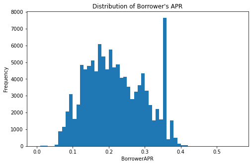

## Distribution of Loan Original Amount

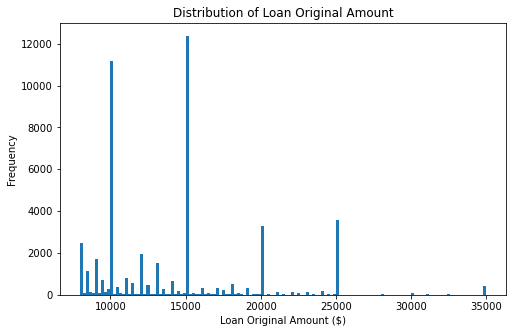

## Relationship between Borrower APR and Prosper Rating

- The Borrower APR decreases with the better rating (Prosper Rating (Alpha)). Borrowers with the best Prosper Ratings have the lowest APR. It means that the Prosper Rating (Alpha) has a strong effect on Borrower APR.

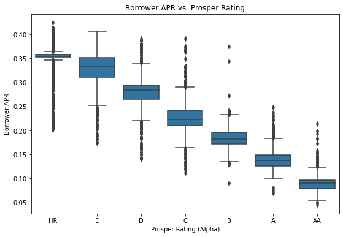

## Effect of Prosper Rating on Relationship between Borrower APR and Loan Original Amount

- The Loan Original Amount increases with better Prosper Rating (Alpha) score.
- The Borrower APR decreases with better Prosper Rating (Alpha) score.
- Interestingly, the relationship between Borrower APR and Loan original Amount turns from negative to slightly positive when the Prosper Ratings are increased from HR to A or better. This may be because people with A or AA ratings tend to borrow more money, increasing APR could prevent them from borrowing even more and maximize the profit. But people with lower Prosper Ratings tend to borrow less money, decreasing APR could encourage them to borrow more.

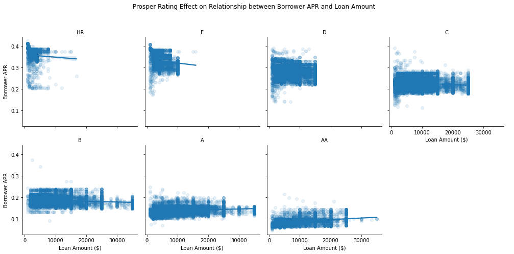

## Effect of Borrower APR across Prosper Rating and Term

- It is noted that the Borrower APR decreases with the increase of loan term (Term) for people with HR-C ProsperRatings. But for people with B-AA ratings, the Borrower APR increases with the increase of loan term (Term).

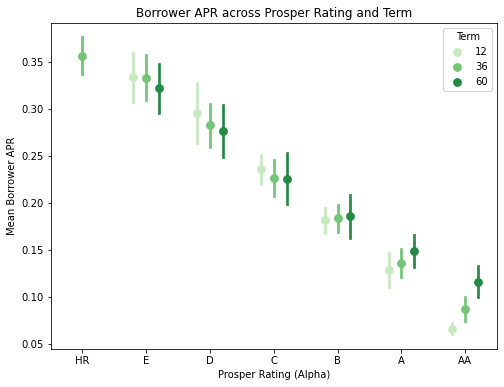